# Intro to R

Women Who Code

April 19th, 2023

# Welcome to Intro to R!

## The RStudio Environment

Hopefully, you have come with R and RStudio installed. If not, Google “R for [your OS]” and “RStudio for [your OS]” to find the download links.

The first thing you will want to do is navigate to the Terminal tab and type `git clone https://github.com/nelariddle/IntroToR.git`. This will automatically extract the files needed today onto your project. (You can choose to navigate to a different directory, or stick with the default.)

Like a lot of other coding software, you can edit R code through projects and files.

- Files can stand on their own.
- Projects are a convenient way of aggregating files together into one folder.
- Projects can be helpful if you plan on accessing external files within your program. R will use the directory the project is stored in, called the “working directory,” to read and save files.

Let’s create a new project.

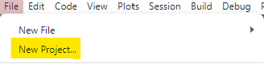

The following options will pop up. You can choose to create a new directory or existing directory, whichever you are more comfortable with. We will not be working with version control today.

[figure not shown]

Now that we have a project, we can begin to explore RStudio.

### The Console

The console, which is currently taking up most of the screen, is where code is executed. You can type code directly into the console and run it from there by pressing `enter`. Try running a simple mathematical expression from the console.

```r
1 + 1
```

```
## [1] 2
```

If you’re working in the console, you can use the up and down arrows to navigate to previous code.

The console is helpful for doing quick computations, but does not actually save your code in any organized manner. RStudio will save your entire console history into an `RData` file, but it can be difficult to sift through the entire thing. This is where the code editor comes in.

### The Code Editor

Using `ctrl+shift+n` or the file pane, create a new R script file. This will give us access to the code editor. This is where we’ll type the bulk of our code. Let’s add a simple line of code:

```r
print("Hello World!")
```

```
## [1] "Hello World!"
```

We can run it by pressing the Run button, which will run the line the cursor is on or whatever is selected. The Source button will run the entire file. The Run shortcut is `ctrl+enter`/`cmd+enter`, and the Source shortcut is `ctrl+alt+r`/`cmd+option+r`.

We can also add comments into our code that allow us to have regular text alongside code we can run. Use the `#` to denote a comment:

```r
# Baby's first R comment :)
```

At this point, we should probably save our file. You can use the regular `ctrl+s`/`cmd+s`. Notice how it appears in the “Files” section in the bottom right after saving.

Try running this code from the code editor or console.

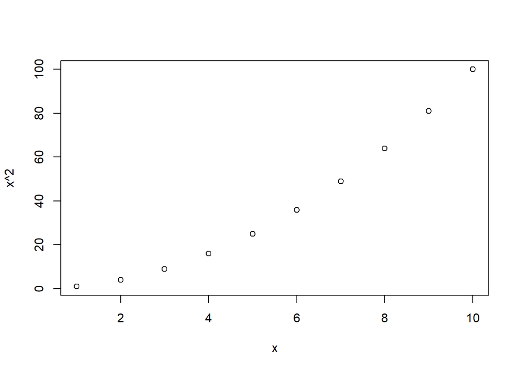

```r
x <- 1:10
plot(x, x ^ 2)
```

Here we’ve created our first variable and plot. Notice how `x` appears in the “Environment” section, and the plot automatically appears in the “Plots” section. These two panels will be important for viewing our data.

## R Data Types

### Main data types

R has several main data types. We can create a variable, or “assign” it, with the `<-` syntax. Here we’ll demonstrate one of each type:

```r
double <- 5
integer <- 5L # need the L to designate an integer; not used often
character <- "I love R"
logical <- TRUE
complex <- 3i
```

We can check what is stored in a variable by calling typeof().

```r
double
```

```
## [1] 5
```

```r
typeof(double)
```

```
## [1] "double"
```

Generally, you will want to avoid naming variables the literal R datatypes to avoid confusing the system. Some variable naming conventions include camel case:

```r
theNameOfTheVariable <- "stuff"
```

or snake case:

```r
the_name_of_the_variable <- "other stuff"
```

In general, it is good to use concise but descriptive names.

R has some helpful functions for converting between data types. They usually take the form “as.[type to convert to]()”.

```r
accidentalCharacter <- "20"
number <- as.numeric(accidentalCharacter)
number + 1 # we can do math on it!
```

```
## [1] 21
```

Functions like that are good for data cleaning, when you need variables to be of a certain type.

### Data structures

Next we’ll learn about data structures in R, or ways of storing multiple things in one place.

#### Vectors

The first is an atomic vector - a vector with only one data type in it. These could be considered the building blocks of R. Let’s create an atomic vector with some numbers in it:

```r
num_vec <- c(1, 2, 3, 4, 5)
```

The c stands for concatenate! We can check the type of the vector using `typeof()` and its length using `length()`:

```r
typeof(num_vec)
```

```
## [1] "double"
```

```r
length(num_vec)
```

```
## [1] 5
```

We can access vector elements by “indexing” them with square brackets. That looks something like this:

```r
num_vec[1] # R indexes from 1
```

```
## [1] 1
```

There are some convenient other ways of creating a vector in R.

```r
num_vec <- 1:10
num_vec
```

```
##  [1]  1  2  3  4  5  6  7  8  9 10
```

```r
num_vec <- 10:1
num_vec
```

```
##  [1] 10  9  8  7  6  5  4  3  2  1
```

More complex sequences of numbers can be created using `seq()`. We can get information about a function directly within R:

```r
# help(seq) or ?seq
seq(from = 1, to = 10, by = 3)
```

```
## [1]  1  4  7 10
```

```r
seq(1, 10, 3)
```

```
## [1]  1  4  7 10
```

Notice how we can choose to provide the argument names or not.

#### Names

Vectors in R can also have attributes. Attributes are kind of like metadata, or data about the vector itself. `names` is one attribute we can add:

```r
abc <- c("apple", "balloon", "carrot")
names(abc) <- c("fruit", "object", "vegetable")
abc
```

```
##     fruit    object vegetable
##   "apple" "balloon"  "carrot"
```

Adding names gives us a new way of indexing our vector!

```r
abc["fruit"]
```

```
##   fruit
## "apple"
```

```r
abc[1]
```

```
##   fruit
## "apple"
```

#### Indexing vectors

If we wanted to get multiple elements, we can actually index a vector with a vector! We could do that like so:

```r
abc[c(1, 2)]
```

```
##     fruit    object
##   "apple" "balloon"
```

```r
abc[1:2]
```

```
##     fruit    object
##   "apple" "balloon"
```

We can also index a vector based on some boolean condition (something that’s true or false), also known as a logical. Here’s a simple function that tells us if one string can be found within another.

```r
grepl("o", "orange") # calling a function on a string
```

```
## [1] TRUE
```

```r
grepl("o", abc) # calling a function on a vector
```

```
## [1] FALSE  TRUE  TRUE
```

```r
abc[grepl("o", abc)] # function as an index
```

```
##    object vegetable
## "balloon"  "carrot"
```

So if we have a logical vector that’s the same length as another one, we can use it to index that vector!

Without running it, what do you think this code would do?

```r
nums <- 1:10
nums[nums %% 2 == 0] # R's modulus operator
```

#### Vectorized operations

The vector-wise operations in R are really versatile! Here we can find the total number of `TRUE`’s in a logical vector:

```r
sum(grepl("o", abc))
```

```
## [1] 2
```

Just as we’d use `and`, `or`, and `not` in other languages on individual booleans, we can combine logical vectors in R with `&`, `|`, and `!` in R.

```r
abc[grepl("o", abc) & grepl("l", abc)]
```

```
##    object
## "balloon"
```

What would the output be if we changed `&` to `|`?

#### Class

Class is another attribute in R that tells us the overarching data structure type. We can get the class like this:

```r
nums <- 1:10
class(nums)
```

```
## [1] "integer"
```

R doesn’t actually recognize a vector as being anything more than its internal type! We will see how this changes with other data structures.

#### Dims, arrays, and matrices

There are a couple of additional data types in R that are technically vectors: matrices and arrays. These are vectors with a new attribute, called `dims`, or the number of dimensions.

- Arrays are vectors with more than one dimension.
- Matrices are arrays with exactly two dimensions.

We can create a matrix by passing a vector to the `matrix` function.

```r
nums <- 1:12
mat <- matrix(nums, nrow = 3, ncol = 4)
mat
```

```
##      [,1] [,2] [,3] [,4]
## [1,]    1    4    7   10
## [2,]    2    5    8   11
## [3,]    3    6    9   12
```

```r
class(mat)
```

```
## [1] "matrix" "array"
```

What happens if we pick two dimensions that don’t multiply to 12?

```r
matrix(nums, nrow = 4, ncol = 4)
```

Here we see that R is pretty flexible.

In `mat`, we can see that the first three elements from `nums` make up the first column. What if we wanted the elements to be placed row-wise instead? Use `?matrix` to see what argument we could change.

With matrices, we gain a few extra attributes:

```r
dim(mat)
```

```
## [1] 3 4
```

```r
nrow(mat)
```

```
## [1] 3
```

```r
ncol(mat)
```

```
## [1] 4
```

Instead of `names()`, we call `dimnames()` to set the names for each row and column.

```r
dimnames(mat) <- list(c("a", "b", "c"), c("d", "e", "f", "g"))
mat
```

```
##   d e f  g
## a 1 4 7 10
## b 2 5 8 11
## c 3 6 9 12
```

`rownames()` and `colnames()` are two additional attributes of matrices we can use:

```r
rownames(mat)
```

```
## [1] "a" "b" "c"
```

```r
colnames(mat)
```

```
## [1] "d" "e" "f" "g"
```

#### Indexing matrices

To index matrices, we now have many different options. We can still access by a single index like before:

```r
mat[1]
```

```
## [1] 1
```

This tells us that vectors preserve their prior ordering when converted to matrices; they are simply laid out differently.

If we know the element’s row and column, we can access it like this:

```r
mat[2, 3]
```

```
## [1] 8
```

```r
mat["b", "f"]
```

```
## [1] 8
```

Or, to pull an entire row/column, we can leave out one index, but keep the comma, like so:

```r
mat[3,]
```

```
##  d  e  f  g
##  3  6  9 12
```

```r
mat[, "g"]
```

```
##  a  b  c
## 10 11 12
```

#### Practicing matrix operations

Let’s practice some matrix operations with a built-in R dataset, called `UCBAdmissions`.

```r
data <- UCBAdmissions
class(data) # table, but behaves like an array
```

```
## [1] "table"
```

Recall how to look at the attributes of an array:

```r
dimnames(data)
```

```
## $Admit
## [1] "Admitted" "Rejected"
##
## $Gender
## [1] "Male"   "Female"
##
## $Dept
## [1] "A" "B" "C" "D" "E" "F"
```

```r
dim(data)
```

```
## [1] 2 2 6
```

```r
data
```

```
## , , Dept = A
##
##           Gender
## Admit      Male Female
##   Admitted  512     89
##   Rejected  313     19
##
## , , Dept = B
##
##           Gender
## Admit      Male Female
##   Admitted  353     17
##   Rejected  207      8
##
## , , Dept = C
##
##           Gender
## Admit      Male Female
##   Admitted  120    202
##   Rejected  205    391
##
## , , Dept = D
##
##           Gender
## Admit      Male Female
##   Admitted  138    131
##   Rejected  279    244
##
## , , Dept = E
##
##           Gender
## Admit      Male Female
##   Admitted   53     94
##   Rejected  138    299
##
## , , Dept = F
##
##           Gender
## Admit      Male Female
##   Admitted   22     24
##   Rejected  351    317
```

How could we just look at Department C? At admits? We’ll need more commas since we have more dimensions:

```r
data[, , "C"] # because "Dept" is the last dimension
```

```
##           Gender
## Admit      Male Female
##   Admitted  120    202
##   Rejected  205    391
```

```r
data["Admitted", ,] # because "Admit" is the first dimension
```

```
##         Dept
## Gender     A   B   C   D   E   F
##   Male   512 353 120 138  53  22
##   Female  89  17 202 131  94  24
```

We can use the `proportions()` function to find probabilities for admittance, stratified by a certain dimension.

```r
proportions(data, margin = c("Gender", "Dept")) # will show us proportions across every possible gender/dept combination
```

```
## , , Dept = A
##
##           Gender
## Admit            Male     Female
##   Admitted 0.62060606 0.82407407
##   Rejected 0.37939394 0.17592593
##
## , , Dept = B
##
##           Gender
## Admit            Male     Female
##   Admitted 0.63035714 0.68000000
##   Rejected 0.36964286 0.32000000
##
## , , Dept = C
##
##           Gender
## Admit            Male     Female
##   Admitted 0.36923077 0.34064081
##   Rejected 0.63076923 0.65935919
##
## , , Dept = D
##
##           Gender
## Admit            Male     Female
##   Admitted 0.33093525 0.34933333
##   Rejected 0.66906475 0.65066667
##
## , , Dept = E
##
##           Gender
## Admit            Male     Female
##   Admitted 0.27748691 0.23918575
##   Rejected 0.72251309 0.76081425
##
## , , Dept = F
##
##           Gender
## Admit            Male     Female
##   Admitted 0.05898123 0.07038123
##   Rejected 0.94101877 0.92961877
```

Note that women outperform men in all but two departments (C and E).

What happens when we make `Dept` our only margin?

```r
proportions(data, margin = "Dept")
```

Let’s look at the overall acceptance rates by gender. We can use `rowSums()` to add up the totals across all the departments. Since `Admit` was the first dimension, it is considered the “row” dimension.

```r
rowSums(data)
```

```
## Admitted Rejected
##     1755     2771
```

```r
rowSums(data, dims = 2) # dims = 2 lets us look at gender and admittance
```

```
##           Gender
## Admit      Male Female
##   Admitted 1198    557
##   Rejected 1493   1278
```

(R also has `colSums()`, but unfortunately no generalized “dimSums” :( )

Let’s use `proportions()` again…

```r
proportions(rowSums(data, dims = 2), margin = "Gender")
```

```
##           Gender
## Admit           Male    Female
##   Admitted 0.4451877 0.3035422
##   Rejected 0.5548123 0.6964578
```

Here we see a textbook example of Simpson’s Paradox, where the trend in admittance reverses when looking at the entire population.

#### Levels and factors

One more attribute we should discuss is `levels`. Levels only belong to a certain type of atomic vector called a `factor`, or R’s way of representing of categorical data.

```r
genders <- c("Male", "Female", "Female", "Male")
genders <- factor(genders)
genders
```

```
## [1] Male   Female Female Male
## Levels: Female Male
```

```r
class(genders)
```

```
## [1] "factor"
```

```r
typeof(genders)
```

```
## [1] "integer"
```

```r
as.numeric("Male") # doesn't work
```

```
## [1] NA
```

```r
genders[1]
```

```
## [1] Male
## Levels: Female Male
```

```r
as.numeric(genders[1])
```

```
## [1] 2
```

Factors are a way to cleanly store data when we know there are only a handful of possibilities for a vector.

#### Lists

Another data structure in R is the list. Unlike atomic vectors, lists can contain multiple data types and even other lists.

```r
my_list <- list("Jane", 32, c(1, 2, 3), TRUE)
typeof(my_list)
```

```
## [1] "list"
```

```r
length(my_list)
```

```
## [1] 4
```

We can access the elements of a list using double brackets [[]]:

```r
my_list[[1]]
```

```
## [1] "Jane"
```

Lists can have attributes too; let’s give the list `names`.

```r
names(my_list) <- c("name", "number", "vector", "logical")
my_list
```

```
## $name
## [1] "Jane"
##
## $number
## [1] 32
##
## $vector
## [1] 1 2 3
##
## $logical
## [1] TRUE
```

What are those dollar signs doing there? Well, with lists, we gain a new way of accessing elements, provided they have names.

```r
my_list$name
```

```
## [1] "Jane"
```

You might have noticed the $ pop up earlier: `dimnames()` actually returns a list, and we can use the $ to access individual dimensions’ names.

```r
class(dimnames(data))
```

```
## [1] "list"
```

```r
dimnames(data)$Admit # data is still UCBAdmissions
```

```
## [1] "Admitted" "Rejected"
```

Lists aren’t used nearly as frequently as atomic vectors. However, they are one of the building blocks of our most important data structure: data frames.

### Data frames

Data frames are essentially lists of atomic vectors of the same length. They are used to store tabular data, similarly to a spreadsheet. We can create a data frame using the data.frame() function:

```r
df <-
  data.frame(
    name = c("John", "Jane", "Joe"),
    age = c(32, 28, 42),
    height = c(175, 160, 180)
  )
class(df)
```

```
## [1] "data.frame"
```

```r
typeof(df)
```

```
## [1] "list"
```

Since a data frame is just a named list, we can access its columns using the $.

```r
df$name
```

```
## [1] "John" "Jane" "Joe"
```

However, because R is awesome, they can also be indexed like matrices! Here’s an example of that:

```r
df[1, 1]
```

```
## [1] "John"
```

```r
df[1, ] # matrix-style row indexing
```

```
##   name age height
## 1 John  32    175
```

```r
df[, 1] # matrix-style column indexing
```

```
## [1] "John" "Jane" "Joe"
```

```r
df[1] # list indexing with numerical index
```

```
##   name
## 1 John
## 2 Jane
## 3  Joe
```

```r
df["name"] # list indexing with name index
```

```
##   name
## 1 John
## 2 Jane
## 3  Joe
```

(One thing to note: if a column name contains spaces, you need to surround it with ``, eg df$`Movie Title`).

We can view the contents of the data frame using the Environment tab again.

We’ll get more into data frames later, but let’s take a quick detour.

## Programming constructs

Programming constructs consist of the building blocks of code that belong to most programming languages: conditionals, loops, and functions.

The syntax for conditionals is very standard:

```r
x <- 10
if (x > 5) {
  print("x is greater than 5")
} else {
  print("x is less than or equal to 5")
}
```

```
## [1] "x is greater than 5"
```

Remember how vectors are the building blocks of R? This means we get a vector analog for every programming construct. Here’s the previous code but using the vectorized `ifelse`:

```r
print(ifelse(x > 5, "x is greater than 5", "x is less than or equal to 5"))
```

```
## [1] "x is greater than 5"
```

```r
x <- 4:6 # x as a vector
print(ifelse(x > 5, "x is greater than 5", "x is less than or equal to 5"))
```

```
## [1] "x is less than or equal to 5" "x is less than or equal to 5"
## [3] "x is greater than 5"
```

Now let’s look at loops. R has both `for` and `while` loops. Here’s the basic syntax of a for loop:

```r
for (i in 1:5) {
  print(i)
}
```

```
## [1] 1
## [1] 2
## [1] 3
## [1] 4
## [1] 5
```

Note that, when the code inside the brackets is only one line, we can exclude the brackets:

```r
for (i in 1:5)
  print(i)
```

```
## [1] 1
## [1] 2
## [1] 3
## [1] 4
## [1] 5
```

Of course there’s a vectorized version of for loops, called `sapply`. Here’s a very basic usage of it:

```r
sapply(1:5, print)
```

```
## [1] 1
## [1] 2
## [1] 3
## [1] 4
## [1] 5
```

```
## [1] 1 2 3 4 5
```

Sapply essentially takes a vector (or other data structure) and a function to perform on each of its elements. The output at the bottom is the “simplified form” and is automatically generated by sapply.

Here are while loops:

```r
i <- 1
while (i <= 5) {
  print(i)
  i <- i + 1
}
```

```
## [1] 1
## [1] 2
## [1] 3
## [1] 4
## [1] 5
```

There’s no vectorized equivalent of `while`, unfortunately.

Finally, let’s discuss functions. A function has to be assigned to be used again. That looks something like this:

```r
area_of_circle <- function(radius) {
  pi * radius ^ 2
}

# calling our function
area_of_circle(2)
```

```
## [1] 12.56637
```

Although it’s important to know that `for` and `if` keywords exist in R, as we’ve seen, there are better ways of running loops over vectors and data frames using vectorized operations. Although we won’t get into them today, R also has `apply`, `lapply`, `sapply`, `vapply`, `mapply`, and `map` for more complicated loops over different data structures. They are very use case-based and difficult to demonstrate, but I would encourage you look into using them on your own time.

## Importing data

Now that we know how to plenty of operations and data frames, let’s examine how to actually import our data into a usable form in R.

R has some built-in datasets, such as `UCBAdmissions` from earlier, that we can view with `data()`. We can practice on those, but optimally, we’d like to work on our own datasets. This can be done in a few ways:

- Connecting to a database system such as MySQL
- Using an R package to access an API, or Application Programming Interface
- Loading from a file on your computer

Today, all we are going to demonstrate is the last one. R accepts many different file types, including CSV, Excel, JSON, XML, etc.

To read a CSV, we can use the built-in `read.csv()`. `?read.csv` tells us all the argument options. There are a lot, but today we’re going to use `na.strings`, which enables us automatically convert blank cells and “Unknown”s to `NA`, which stands for “Not Available.” It is good practice in R to have missing values be marked as `NA`. We also choose `sep = ";"` because this particular file is semicolon-separated.

```r
hp <-
  read.csv2(
    "Characters.csv",
    na.strings = c("", "Unknown"),
    sep = ";",
    stringsAsFactors = TRUE,
    encoding = "UTF-8"
  )
```

Since the file is contained directly in our project folder, we only need to supply the file’s name. If it was in some subfolder, like “data,” we would rewrite the file path as “data/Characters.csv”.

## Plotting

We can visualize what’s in the data frame using this command:

```r
# head(hp)
```

Or by simply viewing it from the “Environment” tab.

Since a data frame behaves like a matrix, we can still use the `colnames()` function to view its column names:

```r
colnames(hp)
```

```
##  [1] "Id"           "Name"         "Gender"       "Job"          "House"
##  [6] "Wand"         "Patronus"     "Species"      "Blood.status" "Hair.colour"
## [11] "Eye.colour"   "Loyalty"      "Skills"       "Birth"        "Death"
```

And we can use the `$` to access its columns.

```r
head(hp$Patronus)
```

```
## [1] Stag                 Jack Russell terrier Otter
## [4] Phoenix              None                 Non-corporeal
## 19 Levels: Boar Cat Doe Fox Goat Hare Horse ... Wolf
```

Here, `hp$Patronus`, or any of the other columns, will just return a regular vector.

We will practice some of the base R plots with this dataset. Let’s start with a simple bar graph. The base R command is `barplot()`, and it accepts a table as input. We can generate that with the `table()` command:

```r
table(hp$House)
```

```
##
## Beauxbatons Academy of Magic         Durmstrang Institute
##                            3                            1
##                   Gryffindor                   Hufflepuff
##                           38                           13
##                    Ravenclaw                    Slytherin
##                           18                           28
```

which we can then input into `barplot()`:

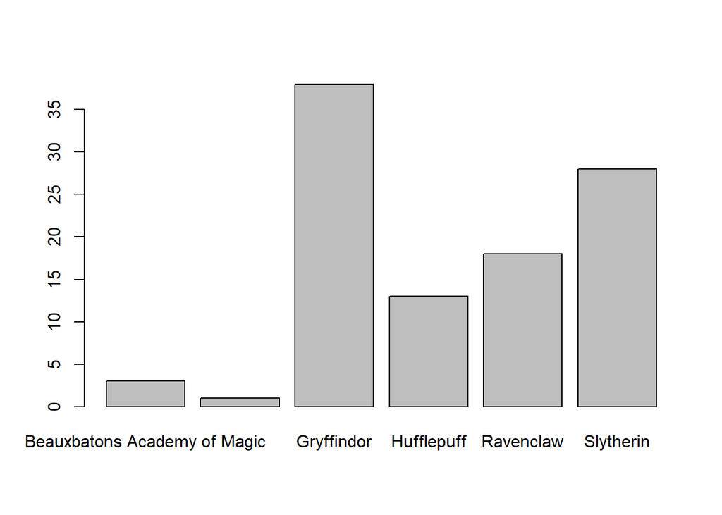

```r
barplot(table(hp$House))
```

Let’s remove Beauxbatons Academy of Magic and Durmstrang Institute. Remember how we can subset a vector by a boolean condition?

```r
hogwartsOnly <-
  hp$House[hp$House != "Beauxbatons Academy of Magic" &
             hp$House != "Durmstrang Institute"]
```

Now let’s plot the reduced vector…

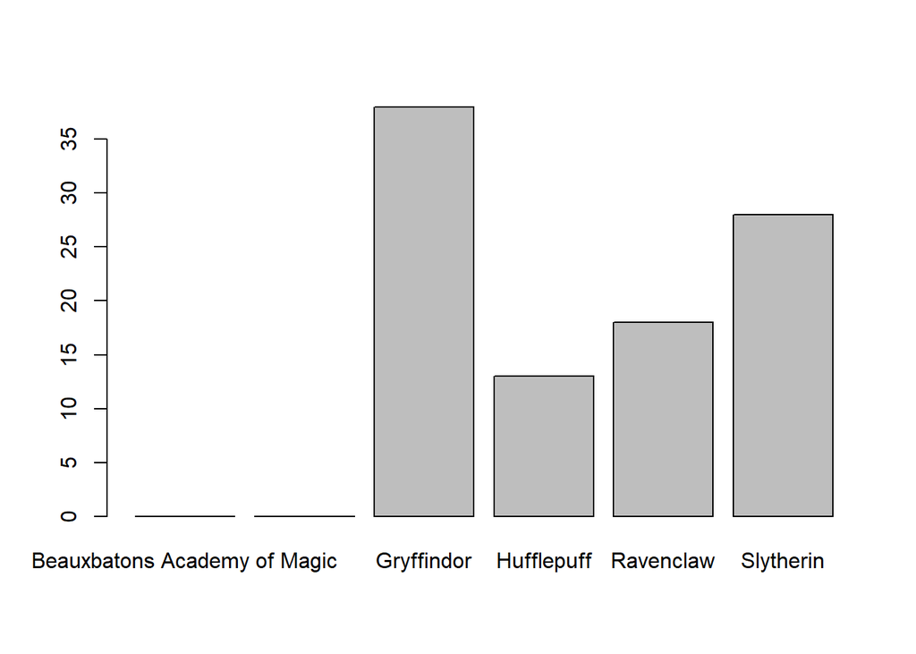

```r
barplot(table(hogwartsOnly))
```

Those two still show up because the vector is a factor. Let’s convert it to a character vector to get rid of them:

[figure not shown]

```r
hogwartsOnly <- as.character(hogwartsOnly)
barplot(table(hogwartsOnly))
```

There’s a few extra arguments we can add to make the output look better.

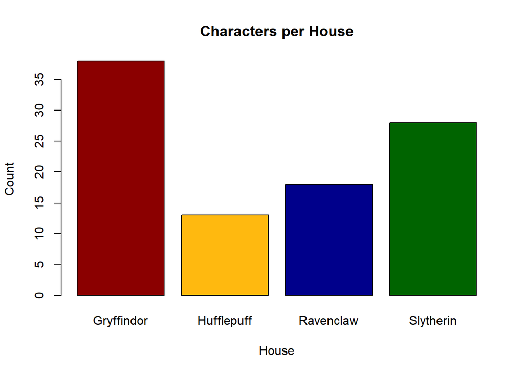

```r
barplot(
  table(hogwartsOnly),
  xlab = "House",
  ylab = "Count",
  main = "Characters per House",
  col = c("darkred", "darkgoldenrod1", "darkblue", "darkgreen")
)
```

A lot of the work in R is just figuring out what function arguments are available and changing them.

Next, let’s learn about the `%>%` operator, called the pipe. We can’t access this until we load the package it’s in, called `dplyr`. That can be done with these commands:

```r
# install.packages("dplyr")
library(dplyr)
```

You can also use the “Install Packages” button under the tools tab.

For more information on dplyr you can visit https://dplyr.tidyverse.org/.

We can do the same filtering as before, but this time with the `filter()` command that is a part of `dplyr`. It will only keep rows that meet the specified condition. Also, the pipe will allow us to conveniently pass an argument (the `hp` data frame) to a function. We can then pipe again to call `droplevels()` to remove the levels from the factor itself.

```r
hogwartsDf <-
  hp %>% filter(House != "Beauxbatons Academy of Magic" &
                  House != "Durmstrang Institute") %>% droplevels()
```

Let’s do the same filtering on `Blood.status`. This time we will use the `%in%` operator. It simply tells you if an element is a member of a vector. For example,

```r
"a" %in% c("a", "b", "c")
```

```
## [1] TRUE
```

We will only select rows whose blood status is “in” the vector of statuses we want.

```r
hogwartsDf <-
  hogwartsDf %>% filter(Blood.status %in% c("Pure-blood", "Half-blood", "Muggle-born")) %>% droplevels()
```

Let’s make a plot called a mosaic plot. It is similar to a barplot but will allow us to visualize counts across two different columns. It accepts a table again, but this time with two different columns.

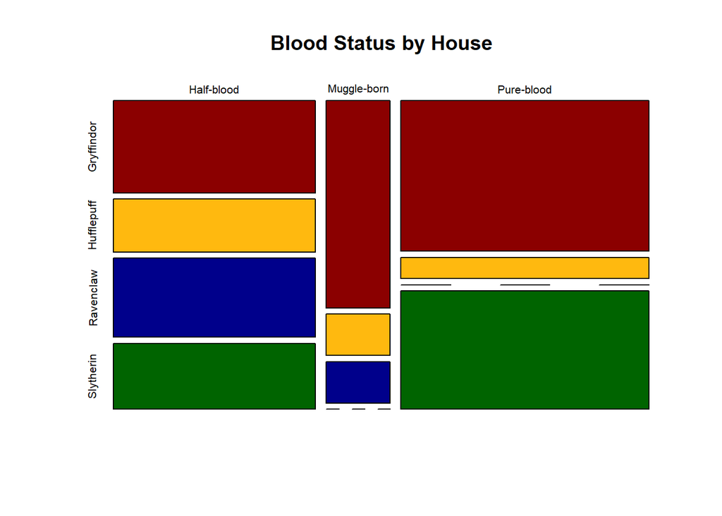

```r
mosaicplot(
  table(hogwartsDf$Blood.status, hogwartsDf$House),
  col = c("darkred", "darkgoldenrod1", "darkblue", "darkgreen"),
  main = "Blood Status by House"
)
```

Now, let’s do something with numerical data. At this point all of our columns are factors, but we can extract numerical data from a column using `mutate()` from dplyr.

First, let’s get the `stringr` package, which will give us more string functionality.

```r
# install.packages(stringr)
library(stringr)
```

`stringr` gives us the command `str_extract`, which will return the first instance of a regex within a string. I have prepared the regex that will get the first four-digit year from a string.

```r
str_extract("Before 1990", "\\d{4}") # example of the function working
```

```
## [1] "1990"
```

In mutate, all we have to do is declare a new column name and assign it what we wish. We’ll call ours `Birth.year`.

```r
birthYearDf <-
  hp %>% filter(House != "Beauxbatons Academy of Magic" &
                  House != "Durmstrang Institute") %>% mutate(Birth.year = as.numeric(str_extract(Birth, "\\d{4}"))) %>% droplevels()
```

The pipe operator is extremely nice for stacking functions to be performed on a single data frame.

Now let’s create a box plot, which is a way of showing the distribution of a continuous variable (birth year). We can simply pass it a vector:

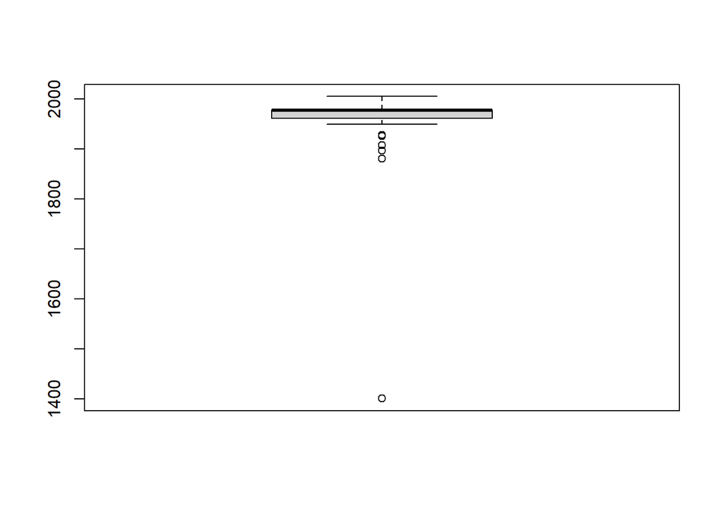

```r
boxplot(birthYearDf$Birth.year)
```

With boxplots, we can also stratify by a categorical variable. To do so, we need to use a “formula,” which comes in the form `y variable ~ x variable`.

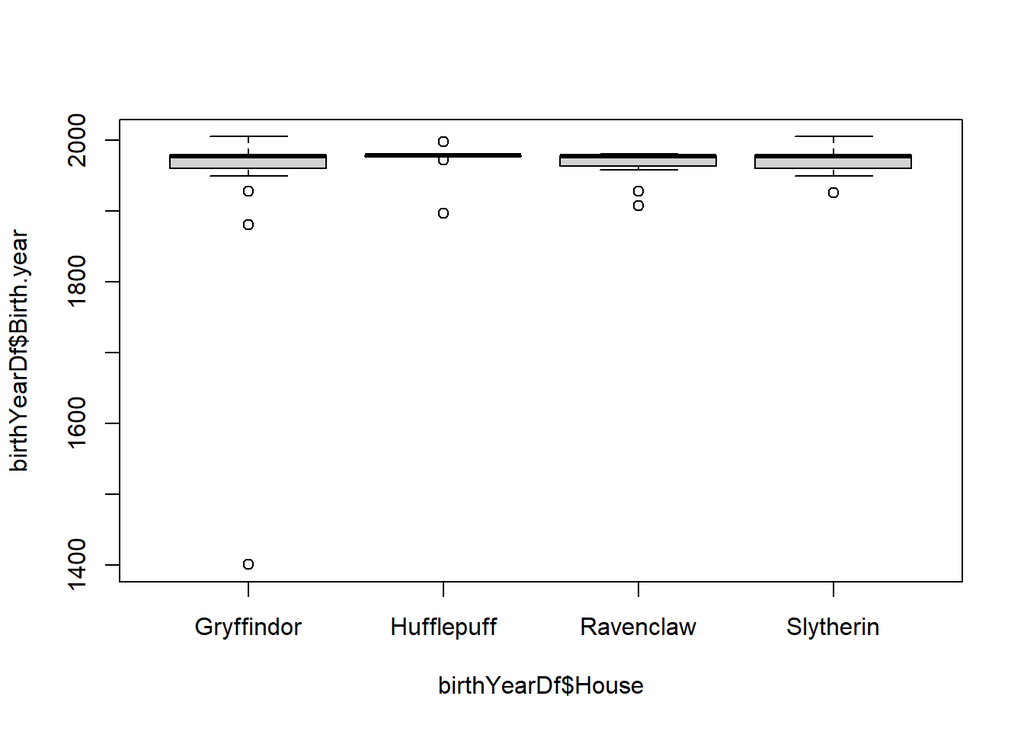

```r
boxplot(birthYearDf$Birth.year ~ birthYearDf$House)
```

Let’s use a pipe this time, which requires we surround the command with `with()`.

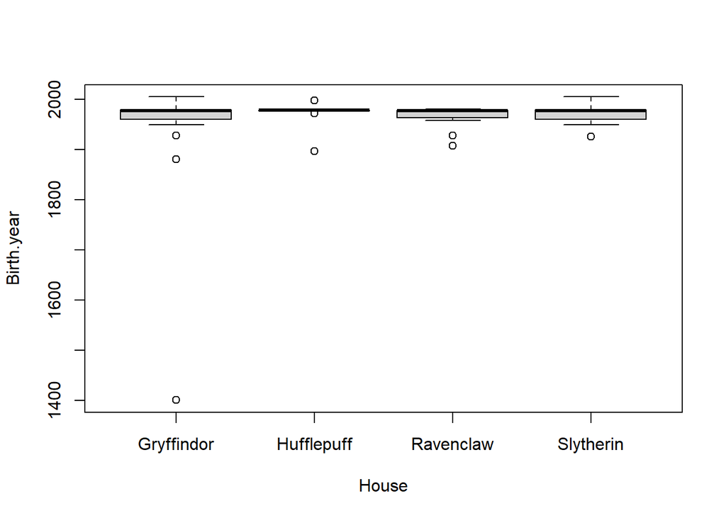

```r
birthYearDf %>% with(boxplot(Birth.year ~ House))
```

This plot doesn’t look great. Let’s remove the outlier by adding another `filter()` pipe. Putting it all together, we get:

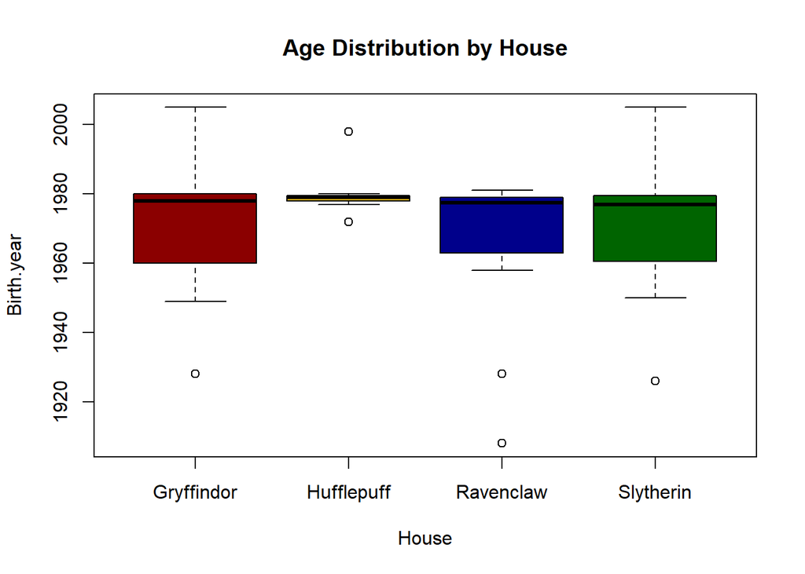

```r
birthYearDf %>% filter(Birth.year > 1900) %>% with(boxplot(
  Birth.year ~ House,
  col = c("darkred", "darkgoldenrod1", "darkblue", "darkgreen"),
  main = "Age Distribution by House"
))
```

Try playing around with some of the`boxplot()` parameters, like `horizontal` (logical), `varwidth` (logical), and `cex.axis` (numeric).

So that’s how you plot in R. Hopefully you feel more comfortable working with R’s built-in data types and some of the plotting functions. R has much more capability than what we described here, so don’t feel limited by this content alone. You can explore `ggplot` for tons more options with plotting.

Finally, let’s learn how to do summary statistics in R. The `summarize()` function from dplyr along with the pipe make this a breeze.

First, let’s add a couple new columns to our data frame:

```r
birthYearDf <-
  birthYearDf %>% mutate(Death.year = as.numeric(str_extract(Death, "\\d{4}")),
                         Life.span = Death.year - Birth.year)
```

Not many entries had both birth and death entries. One condition we can filter by is `is.na`, which will check if a variable is actually present in that row.

```r
deadCharactersDf <- birthYearDf %>% filter(!is.na(Life.span))
```

Now we can calculate some summary statistics about life span. We just need to pipe our data frame into the summarize function and create our statistic variables like so:

```r
deadCharactersDf %>% summarize(
  `Avg Life Span` = mean(Life.span),
  `Median Life Span` = median(Life.span),
  Youngest = min(Life.span),
  Oldest = max(Life.span)
)
```

```
##   Avg Life Span Median Life Span Youngest Oldest
## 1      36.52632               22       15    116
```

```r
deadCharactersDf %>% group_by(Species) %>% summarize(
  `Avg Life Span` = mean(Life.span),
  `Median Life Span` = median(Life.span),
  Youngest = min(Life.span),
  Oldest = max(Life.span)
)
```

```
## # A tibble: 3 x 5
##   Species  `Avg Life Span` `Median Life Span` Youngest Oldest
##   <fct>              <dbl>              <dbl>    <dbl>  <dbl>
## 1 Ghost               53                 53         15     91
## 2 Human               34.4               21.5       17    116
## 3 Werewolf            38                 38         38     38
```

We can even group by multiple variables at once:

```r
deadCharactersDf %>% group_by(Species, Blood.status) %>% summarize(
  `Avg Life Span` = mean(Life.span),
  `Median Life Span` = median(Life.span),
  Youngest = min(Life.span),
  Oldest = max(Life.span)
)
```

```
## # A tibble: 7 x 6
## # Groups:   Species [3]
##   Species  Blood.status             `Avg Life Span` Median Life~1 Young~2 Oldest
##   <fct>    <fct>                              <dbl>         <dbl>   <dbl>  <dbl>
## 1 Ghost    Muggle-born                         15            15        15     15
## 2 Ghost    <NA>                                91            91        91     91
## 3 Human    Half-blood                          54.8          38        22    116
## 4 Human    Half-blood or pure-blood            39            39        39     39
## 5 Human    Muggle-born                         19            19        17     21
## 6 Human    Pure-blood                          24.9          19.5      18     47
## 7 Werewolf Half-blood                          38            38        38     38
## # ... with abbreviated variable names 1: `Median Life Span`, 2: Youngest
```

That’s all for today folks. We hope you enjoyed Intro to R, and hope to see you at future events!